# FA with R

2023-08-10

其實這裏也算簡單一記？實際的筆記使用rstudio然後rmarkdown直接生成一個html咯。好像有點道理。

創建一個向量的價格並繪製：

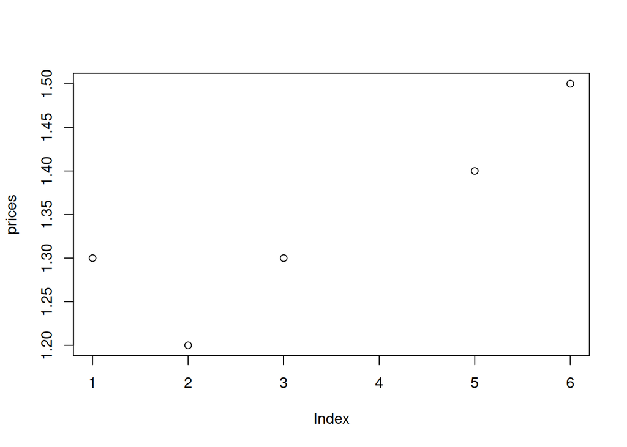

```r
x = c(1.3, 1.2, 1.3, NA, 1.4, 1.5)
plot(x,ylab="prices")
```

```r
is.na(x)
```

```
## [1] FALSE FALSE FALSE  TRUE FALSE FALSE
```

R處理NA，極大值（Inf），非數值(NaN)可以使用三個布爾值函數： is.na() is.infinite() in.nan()

## 語言功能：函數、賦值、參數和類型

過濾

```r
x[x>1.3]
```

```
## [1]  NA 1.4 1.5
```

自然對數函數log()

```r
y <- diff(log(x))
round(y,3)
```

```
## [1] -0.080  0.080     NA     NA  0.069
```

定義函數：

```r
g <- function(x,y=5){return(x^y)}
g
```

```
## function(x,y=5){return(x^y)}
```

```r
g(4,6)
```

```
## [1] 4096
```

R語言的箭頭賦值運算符來自APL。

R語言“超級賦值” `<<`，是執行會在當前之外尋找x，全局中賦值給x，如果全局環境中沒有x，它會創建一個x並賦值給它。

**因爲函數的參數是通過值傳遞的，所以超級賦值運算符是將結果返回調用環境的一種方法。**

## 語言功能：綁定和數組

函數： cbind()將項綁定到兩列

rbind()將項綁定到兩行

rep()創建重複項向量

```r
A = cbind(rep(x,length(y)),y)
B = rbind(rep(x,length(y)),y)
A
```

```
##                     y
##  [1,] 1.3 -0.08004271
##  [2,] 1.2  0.08004271
##  [3,] 1.3          NA
##  [4,]  NA          NA
##  [5,] 1.4  0.06899287
##  [6,] 1.5 -0.08004271
##  [7,] 1.3  0.08004271
##  [8,] 1.2          NA
##  [9,] 1.3          NA
## [10,]  NA  0.06899287
## [11,] 1.4 -0.08004271
## [12,] 1.5  0.08004271
## [13,] 1.3          NA
## [14,] 1.2          NA
```

[output cut: 16 more lines]

```r
B
```

```
##          [,1]       [,2] [,3] [,4]       [,5]        [,6]       [,7] [,8] [,9]
##    1.30000000 1.20000000  1.3   NA 1.40000000  1.50000000 1.30000000  1.2  1.3
## y -0.08004271 0.08004271   NA   NA 0.06899287 -0.08004271 0.08004271   NA   NA
##        [,10]       [,11]      [,12] [,13] [,14]      [,15]       [,16]
##           NA  1.40000000 1.50000000   1.3   1.2 1.30000000          NA
## y 0.06899287 -0.08004271 0.08004271    NA    NA 0.06899287 -0.08004271
##        [,17] [,18] [,19]      [,20]       [,21]      [,22] [,23] [,24]
##   1.40000000   1.5   1.3 1.20000000  1.30000000         NA   1.4   1.5
## y 0.08004271    NA    NA 0.06899287 -0.08004271 0.08004271    NA    NA
##        [,25]       [,26]      [,27] [,28] [,29]      [,30]
##   1.30000000  1.20000000 1.30000000    NA   1.4 1.50000000
## y 0.06899287 -0.08004271 0.08004271    NA    NA 0.06899287
```

```r
t(A) == B
```

```
##   [,1] [,2] [,3] [,4] [,5] [,6] [,7] [,8] [,9] [,10] [,11] [,12] [,13] [,14]
##   TRUE TRUE TRUE   NA TRUE TRUE TRUE TRUE TRUE    NA  TRUE  TRUE  TRUE  TRUE
## y TRUE TRUE   NA   NA TRUE TRUE TRUE   NA   NA  TRUE  TRUE  TRUE    NA    NA
##   [,15] [,16] [,17] [,18] [,19] [,20] [,21] [,22] [,23] [,24] [,25] [,26] [,27]
##    TRUE    NA  TRUE  TRUE  TRUE  TRUE  TRUE    NA  TRUE  TRUE  TRUE  TRUE  TRUE
## y  TRUE  TRUE  TRUE    NA    NA  TRUE  TRUE  TRUE    NA    NA  TRUE  TRUE  TRUE
##   [,28] [,29] [,30]
##      NA  TRUE  TRUE
## y    NA    NA  TRUE
```

```r
B[,4]
```

```
##     y
## NA NA
```

```r
B[,-4]
```

```
##          [,1]       [,2] [,3]       [,4]        [,5]       [,6] [,7] [,8]
##    1.30000000 1.20000000  1.3 1.40000000  1.50000000 1.30000000  1.2  1.3
## y -0.08004271 0.08004271   NA 0.06899287 -0.08004271 0.08004271   NA   NA
##         [,9]       [,10]      [,11] [,12] [,13]      [,14]       [,15]
##           NA  1.40000000 1.50000000   1.3   1.2 1.30000000          NA
## y 0.06899287 -0.08004271 0.08004271    NA    NA 0.06899287 -0.08004271
##        [,16] [,17] [,18]      [,19]       [,20]      [,21] [,22] [,23]
##   1.40000000   1.5   1.3 1.20000000  1.30000000         NA   1.4   1.5
## y 0.08004271    NA    NA 0.06899287 -0.08004271 0.08004271    NA    NA
##        [,24]       [,25]      [,26] [,27] [,28]      [,29]
##   1.30000000  1.20000000 1.30000000    NA   1.4 1.50000000
## y 0.06899287 -0.08004271 0.08004271    NA    NA 0.06899287
```

R最方便的功能之一是負下標。

如果一個向量包含負下標向量，可以從維度中消除一組完整的元素。

R有一個tryCatch()功能（函數）

## 數字、統計和字符函數

設置計算模式時，option(digits = n)可設置計算中要四捨五入的位數。

函數：

runif() 生成均勻分佈

rnorm() 生成正太分佈

rbinom() 生成二項分佈

hist() 繪製直方圖

density() 繪製密度圖

set.seed() 設置隨機種子

sample() 取樣

可以通過繪製density()函數結果，檢驗二項分佈中變量的密度：

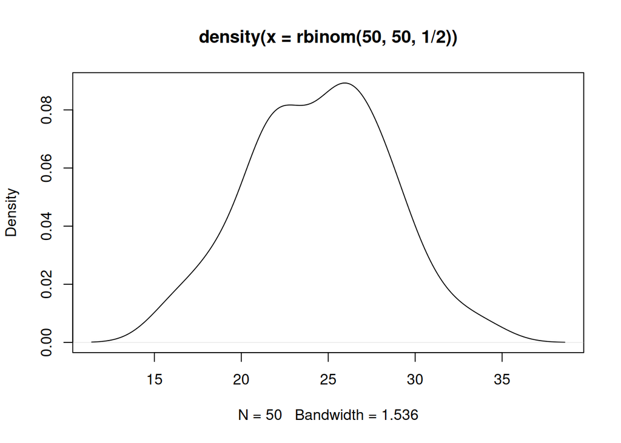

```r
plot(density(rbinom(50,50,1/2)))
```

```r
options(digits=6)
sample(10,replace=TRUE)
```

```
##  [1]  4  6 10  3  5  3  2  4  2 10
```

R通過一組函數來支持字符串。

函數：

paste() 連接字符串

substr() 截取字符串

match() 查找字符串，返回在數組中的位置

## dataframe和輸入輸出

dataframe被typeof()視爲列表。

目錄對於讀寫很重要。使用：

setwd() 設置路徑

getwd() 查看當前路徑

列表是有序集合。

## 資本資產定價模型

```r
library(RSQLite)
library(foreign)
setwd("~/FinAnalytics/ChapXII/")
funda <- read.dta("funda.dta")
msf <- read.dta("msf.dta")
con <- dbConnect(SQLite(),":memory:")
dbWriteTable(con, "funda", funda, overwrite=TRUE)
dbWriteTable(con, "msf", msf, overwrite=TRUE)
command <- "select tsymbol, ret
            from msf
            where date between '2005-01-01' and '2013-12-31'
                  and tsymbol in('AAPL', 'SPY')"
result <- dbGetQuery(con, command)
y <- result[result$tsymbol=='AAPL',]$ret
x <- result[result$tsymbol=='SPY',]$ret
cov(x,y)/var(x)
```

```
## [1] 1.21944
```

```r
summary(lm(y~x+1))
```

```
##
## Call:
## lm(formula = y ~ x + 1)
##
## Residuals:
##      Min       1Q   Median       3Q      Max
## -0.26737 -0.05708  0.00469  0.05200  0.19698
##
## Coefficients:
##             Estimate Std. Error t value Pr(>|t|)
## (Intercept)  0.02446    0.00857    2.85   0.0052 **
## x            1.21944    0.19374    6.29  7.1e-09 ***
## ---
## Signif. codes:  0 '***' 0.001 '**' 0.01 '*' 0.05 '.' 0.1 ' ' 1
##
## Residual standard error: 0.0881 on 106 degrees of freedom
## Multiple R-squared:  0.272,  Adjusted R-squared:  0.265
## F-statistic: 39.6 on 1 and 106 DF,  p-value: 7.11e-09
```

```r
shapiro.test(x)
```

```
##
##  Shapiro-Wilk normality test
##
## data:  x
## W = 0.96, p-value = 0.00253
```

```r
shapiro.test(y)
```

```
##
##  Shapiro-Wilk normality test
##
## data:  y
## W = 0.9692, p-value = 0.0132
```

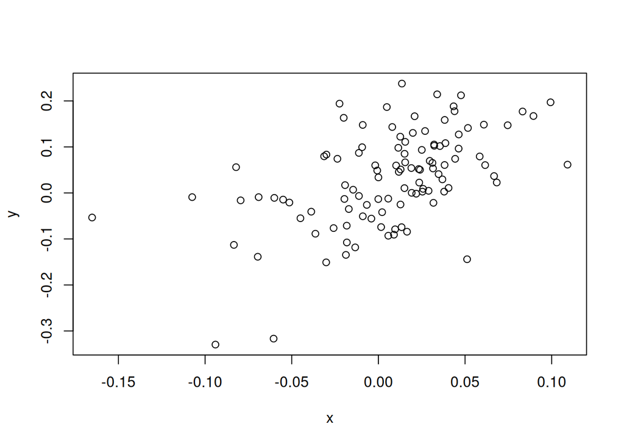

```r
plot(x,y)
```

## 證券數據集和可視化

```
## [1] 1
## [1] "1 MMM"
```

```
## [1] "2 NA"
```

```
## [1] "3 NA"
```

```
## [1] "4 NA"
```

```
## [1] "5 NA"
```

```
## [1] "6 NA"
```

```
## [1] "7 NA"
```

```
## [1] "8 NA"
```

```
## [1] "9 NA"
```

```
## [1] "10 NA"
```

```
## [1] "11 NA"
```

```
## [1] "12 NA"
```

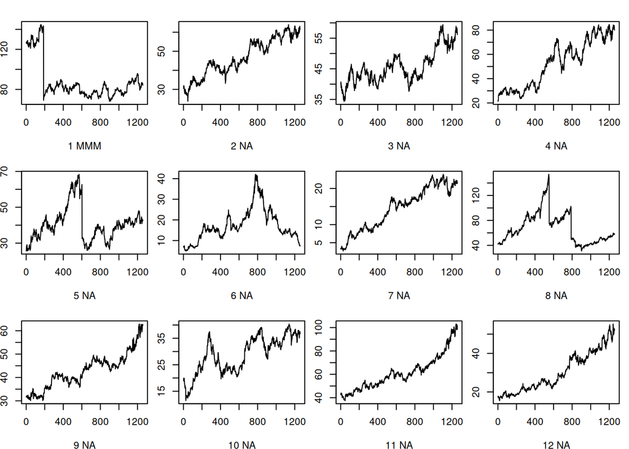

```r
displayCharts <- function(prices,lab,nrow=3,ncol=4,sleepSecs=4) {
  Dims=length(prices[1,])
  for(chartGrp in (1:ceiling(Dims/(nrow*ncol)))){
    print(chartGrp)
    par(mar=c(3.82,1.82,1.82,0.82))
    par(mfrow=c(nrow,ncol))
    for(i in 1:(nrow*ncol)){
      j = ((chartGrp-1)*nrow*ncol+i)
      if(j <= Dims){
        print(paste(j,lab[j]))
        plot(prices[,j],type="l",xlab=paste(j,lab[j]))
      }
    }
    Sys.sleep(sleepSecs)
  }
}

library(huge)
data(stockdata)
D = length(stockdata$data[1,])
len = length(stockdata$data[,1])
prices = stockdata$data[,1:D]
lab = stockdata$info[1:D:1]
displayCharts(prices[,1:12],lab[1:12],sleepSec=30)
```

## 時間序列

```r
library(quantmod)
library(PerformanceAnalytics)
sym.vec <- c("^GSPC","^VIX")
getSymbols(sym.vec,from="2005-01-03", to="2015-09-16")
```

```r
library(TSA)
```

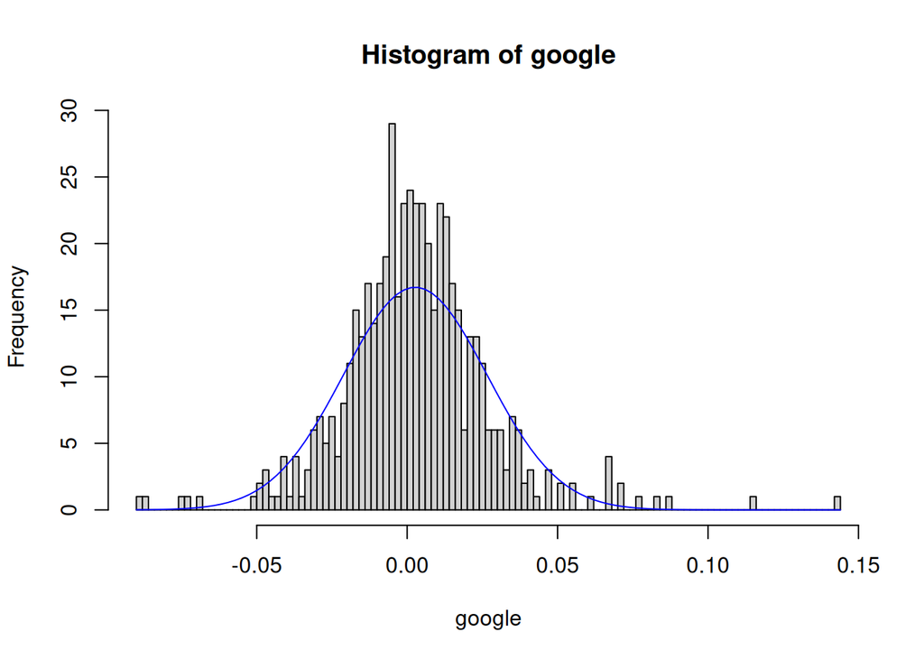

```r
library(ggplot2)
library(tseries)
data(google)
hist(google,breaks=100)
curve(dnorm(x,mean=mean(google),sd=sd(google)),add=TRUE,col='blue')
```

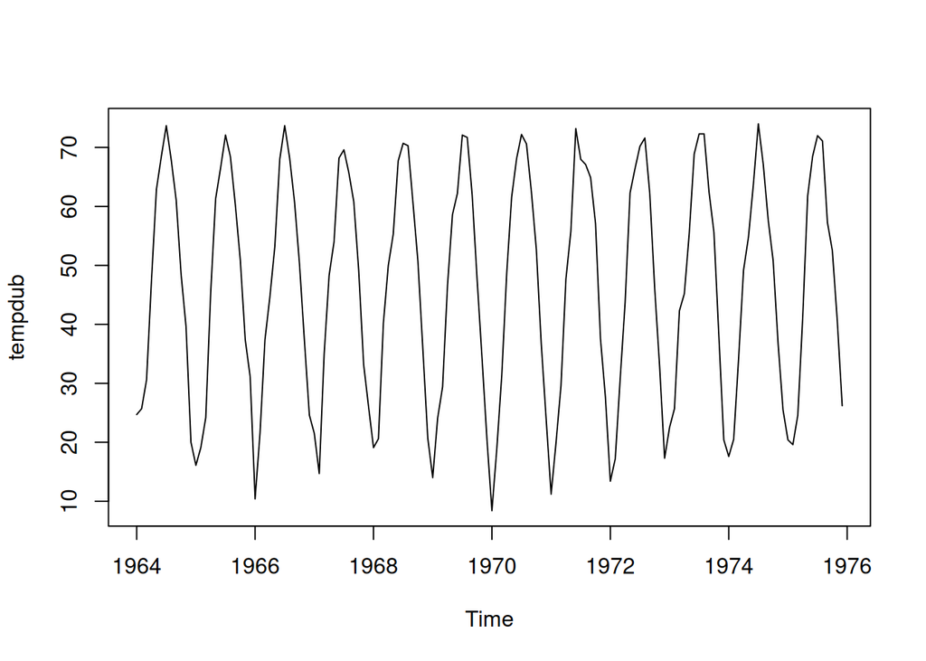

```r
data(tempdub)
plot(tempdub)
```

```r
adf.test(tempdub)
```

```
##
##  Augmented Dickey-Fuller Test
##
## data:  tempdub
## Dickey-Fuller = -11.08, Lag order = 5, p-value = 0.01
## alternative hypothesis: stationary
```

```r
month <- season(tempdub)
model1 <- lm(tempdub ~ month -1)
summary(model1)
```

```
##
## Call:
## lm(formula = tempdub ~ month - 1)
##
## Residuals:
##    Min     1Q Median     3Q    Max
## -8.275 -2.248  0.113  1.890  9.825
##
## Coefficients:
##                Estimate Std. Error t value Pr(>|t|)
## monthJanuary     16.608      0.987    16.8   <2e-16 ***
## monthFebruary    20.650      0.987    20.9   <2e-16 ***
## monthMarch       32.475      0.987    32.9   <2e-16 ***
## monthApril       46.525      0.987    47.1   <2e-16 ***
## monthMay         58.092      0.987    58.9   <2e-16 ***
## monthJune        67.500      0.987    68.4   <2e-16 ***
## monthJuly        71.717      0.987    72.7   <2e-16 ***
## monthAugust      69.333      0.987    70.2   <2e-16 ***
## monthSeptember   61.025      0.987    61.8   <2e-16 ***
## monthOctober     50.975      0.987    51.6   <2e-16 ***
## monthNovember    36.650      0.987    37.1   <2e-16 ***
## monthDecember    23.642      0.987    23.9   <2e-16 ***
## ---
## Signif. codes:  0 '***' 0.001 '**' 0.01 '*' 0.05 '.' 0.1 ' ' 1
##
## Residual standard error: 3.42 on 132 degrees of freedom
## Multiple R-squared:  0.996,  Adjusted R-squared:  0.995
## F-statistic: 2.57e+03 on 12 and 132 DF,  p-value: <2e-16
```

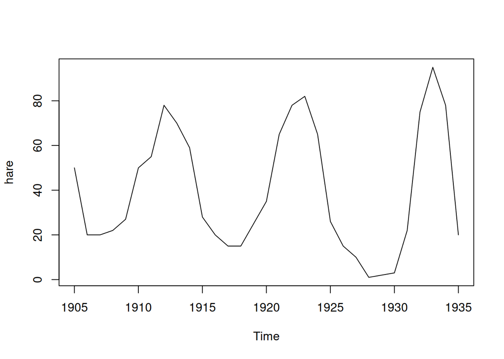

```r
data(hare)
plot(hare)
```

```r
adf.test(hare)
```

```
##
##  Augmented Dickey-Fuller Test
##
## data:  hare
## Dickey-Fuller = -3.505, Lag order = 3, p-value = 0.0606
## alternative hypothesis: stationary
```

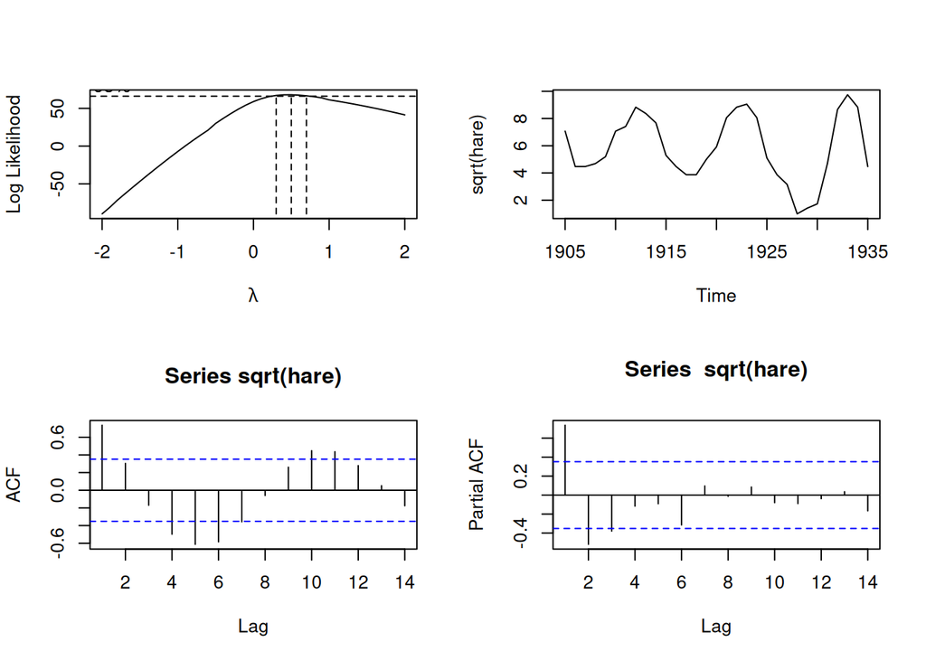

```r
par(mfrow=c(2,2))
BoxCox.ar(hare)
plot(sqrt(hare))
acf(sqrt(hare))
pacf(sqrt(hare))
```

```r
adf.test(sqrt(hare))
```

```
##
##  Augmented Dickey-Fuller Test
##
## data:  sqrt(hare)
## Dickey-Fuller = -4.479, Lag order = 3, p-value = 0.01
## alternative hypothesis: stationary
```

```r
m1.hare <- arima(x=sqrt(hare),order=c(3,0,0))
runs(rstandard(m1.hare))
```

```
## $pvalue
## [1] 0.602
##
## $observed.runs
## [1] 18
##
## $expected.runs
## [1] 16.0968
##
## $n1
## [1] 13
##
## $n2
## [1] 18
##
## $k
## [1] 0
```

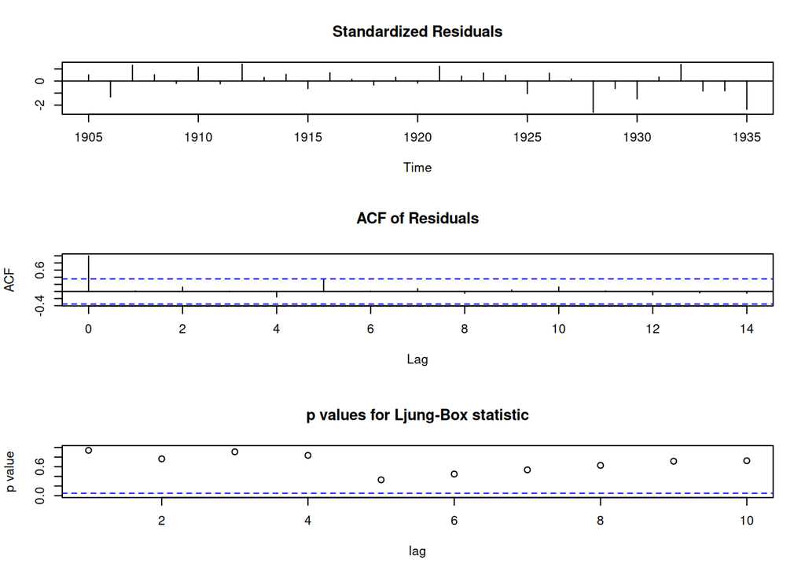

```r
tsdiag(m1.hare)
```

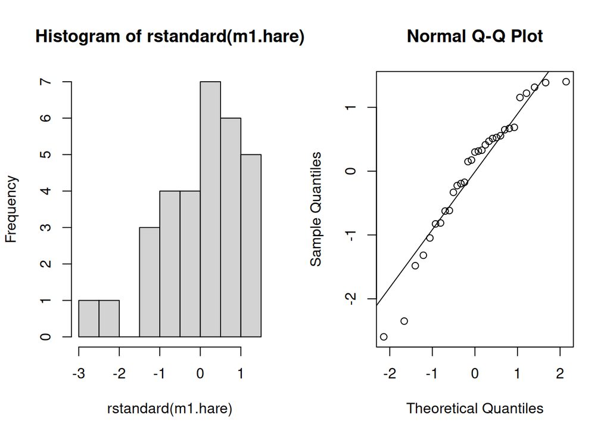

```r
par(mfrow=c(1,2))
hist(rstandard(m1.hare))
qqnorm(rstandard(m1.hare))
qqline(rstandard(m1.hare))
```

```r
shapiro.test(residuals(m1.hare))
```

```
##
##  Shapiro-Wilk normality test
##
## data:  residuals(m1.hare)
## W = 0.9351, p-value = 0.0604
```

未完待續……